# DESeqAnalysis

```r
library(DESeq2)
library(magrittr)
library(EnhancedVolcano)
library(ashr)
library(fgsea)
library(plyr)
library(dplyr)
library(msigdbr)

dds4v5 = readRDS("outputs/dds4v5.rds")
dds4vM = readRDS("outputs/dds4vM.rds")
dds5vM = readRDS("outputs/dds5vM.rds")
```

# Analyzing the DESeq output

Here we run DESeq2 to get our DEGs for our contrasts of choice: We will compare the three different timepoints against each other, generating a total of 3 contrasts. 1. protruding mouth vs day 4 2. day 4 vs day 5 3. protruding mouth vs day 5

```r
dds4v5$stageName <- droplevels(dds4v5$stageName)
dds4vM$stageName <- droplevels(dds4vM$stageName)
dds5vM$stageName <- droplevels(dds5vM$stageName)
dds4v5 = DESeq(dds4v5)
dds4vM = DESeq(dds4vM)
dds5vM = DESeq(dds5vM)
res4v5 <- results(dds4v5)
res4vM <- results(dds4vM)
res5vM <- results(dds5vM)
```

```r
res5vM = lfcShrink(dds=dds5vM, coef = "stageName_Day.5_vs_Protruding.mouth",res = res5vM, type = "ashr")
res4vM = lfcShrink(dds=dds4vM, coef = "stageName_Day.4_vs_Protruding.mouth",res = res4vM, type = "ashr")
res4v5 = lfcShrink(dds4v5, contrast = c("stageName", "Day.4", "Day.5"),res = res4v5, type="ashr")
```

Here we us LFCshrink via ashr to shrink our logfold2 changes from the DESeq outputs with respect to our contrasts. We do not use normal type as ashr and apeglm both outperform normal here.

## Dispersion Estimates

Here we glance into our data to see if the model is well fit to the data:

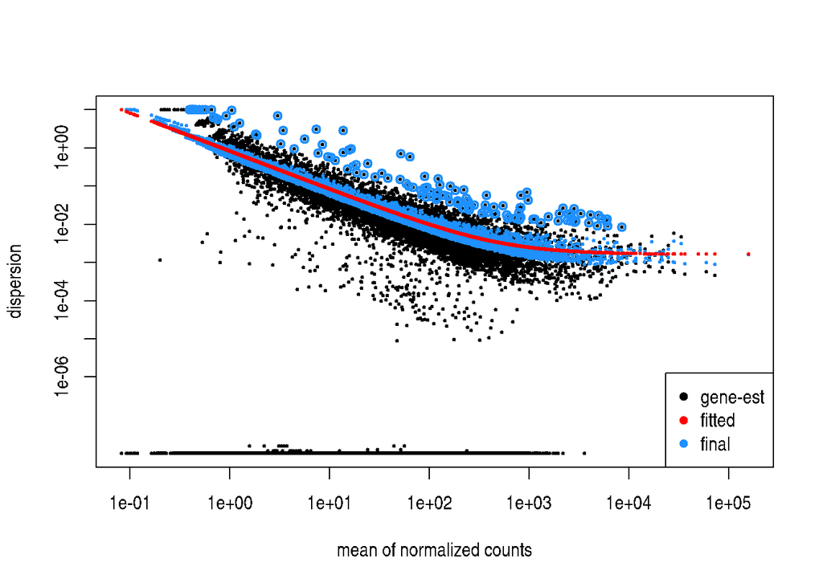

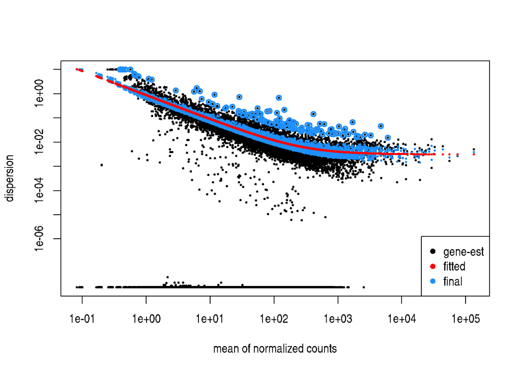

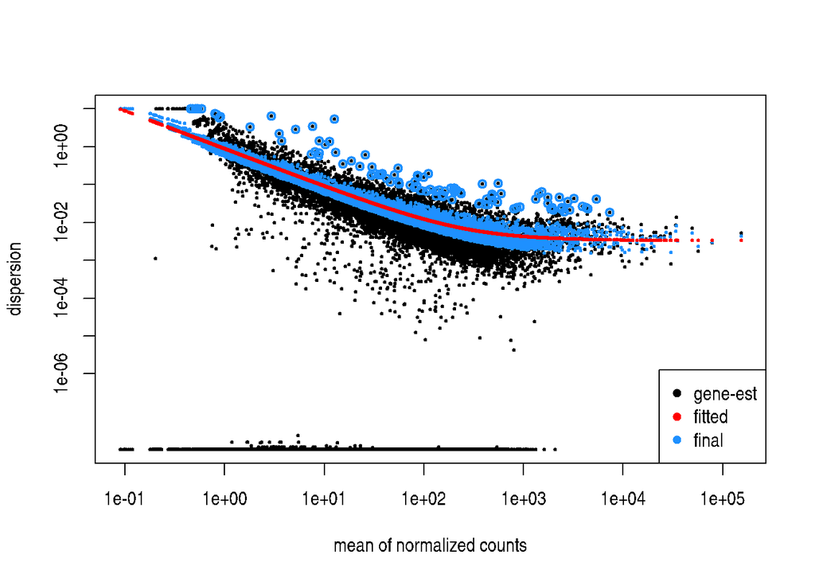

```r
plotDispEsts(dds4v5)
plotDispEsts(dds4vM)
plotDispEsts(dds5vM)
```

Everything looks mostly okay here; it mostly fits the “normal look” here.

## Top Genes expressed in Day 5 vs Mouth Protruding

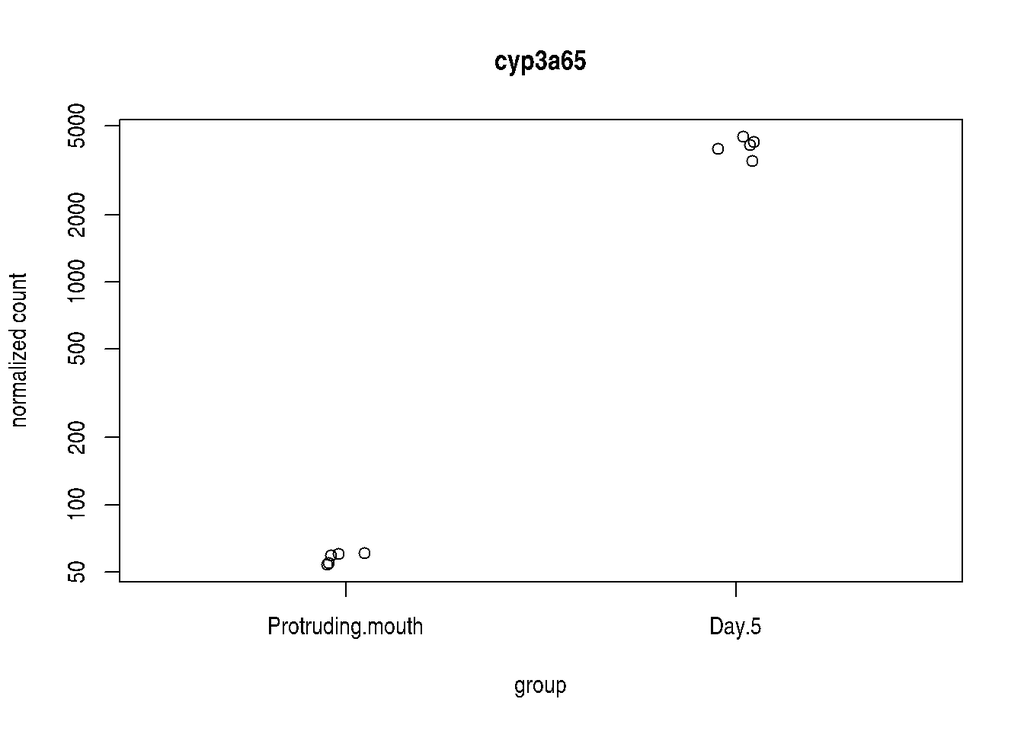

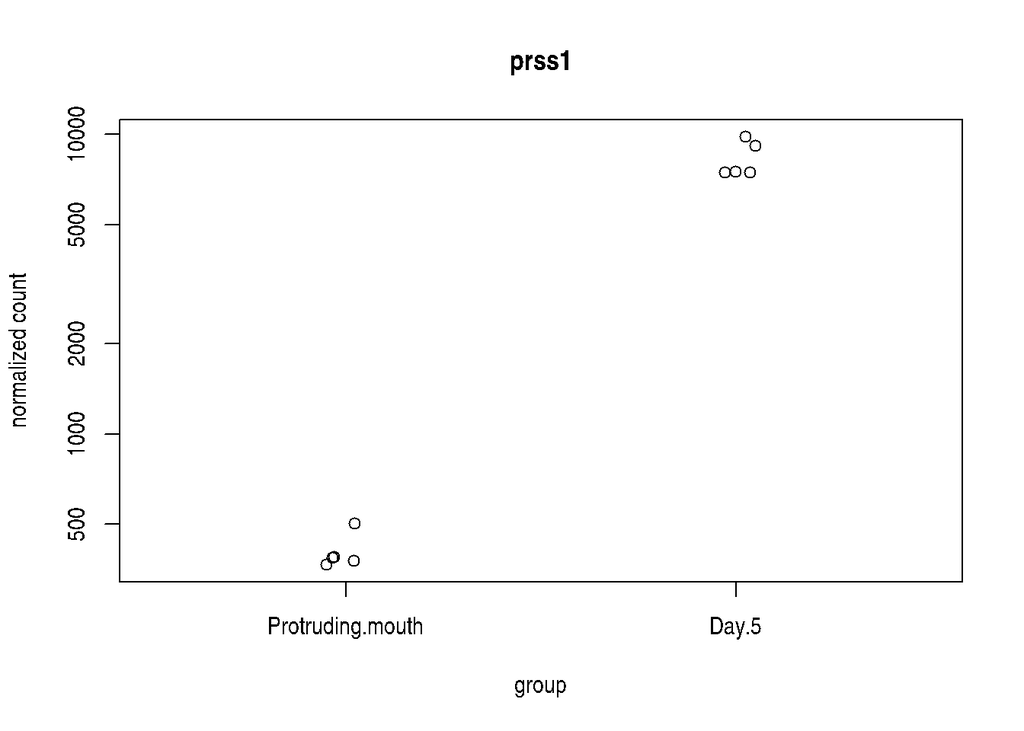

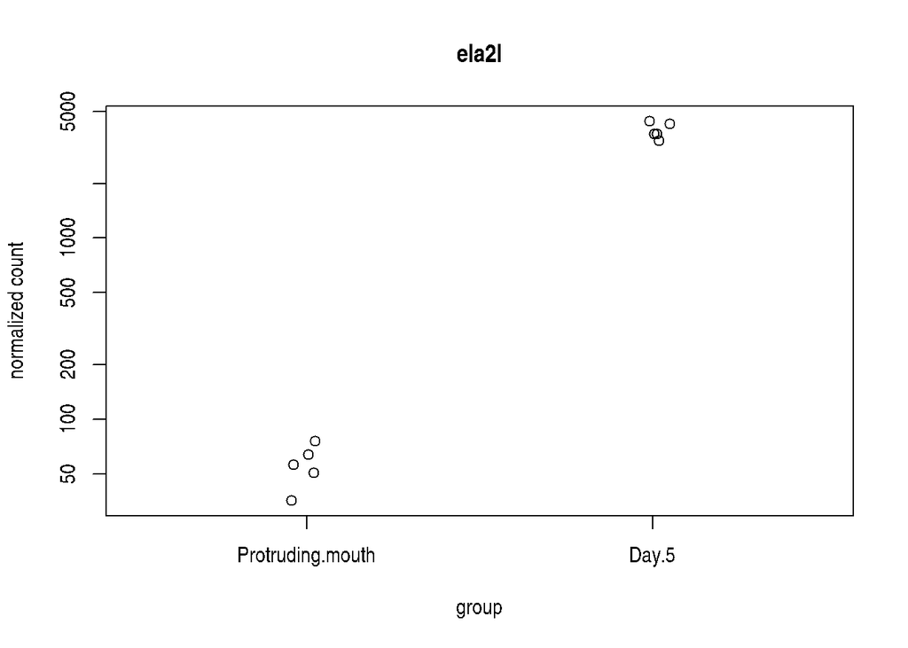

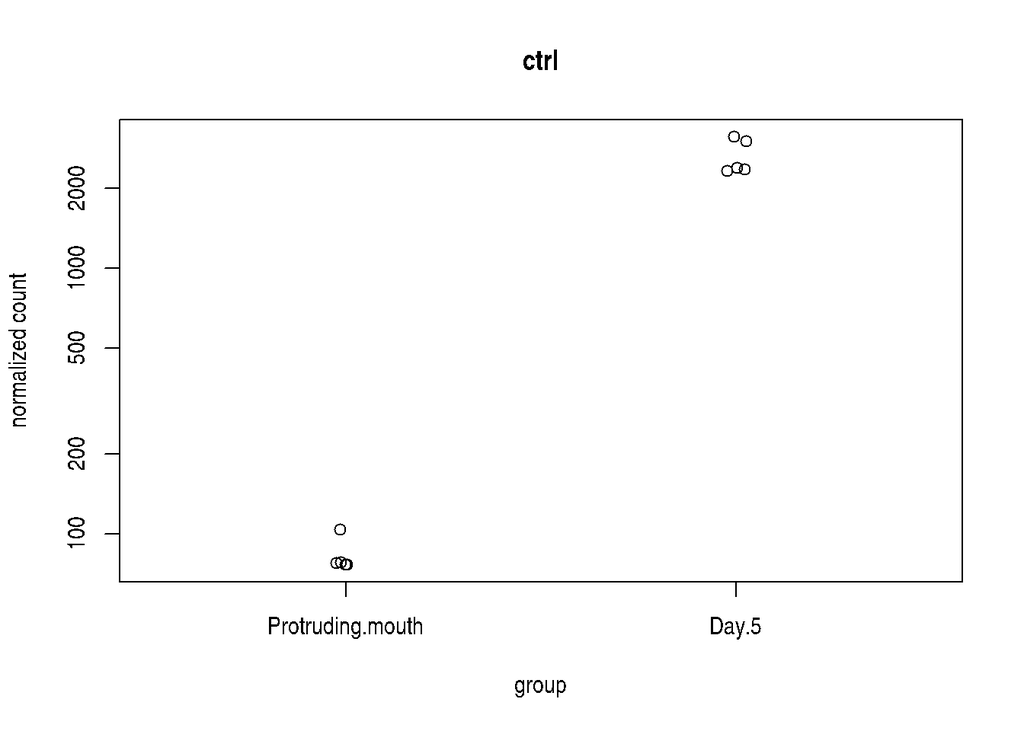

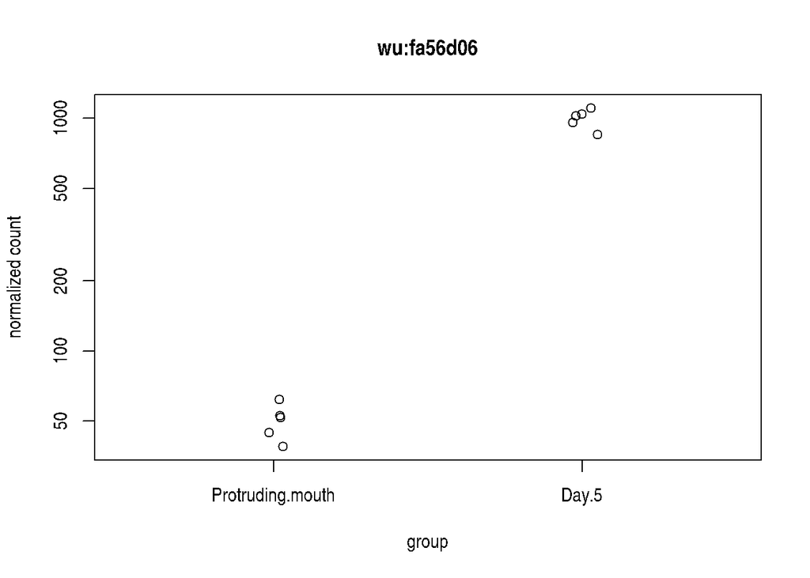

```r
(for (i in order(res5vM$padj, decreasing = F)[1:5]){
  plotCounts(dds5vM, gene=i, intgroup="stageName", main = "")
  title(rowData(dds5vM)[rownames(res5vM[i,]),]$SYMBOL)
})
```

### Volcano Plot

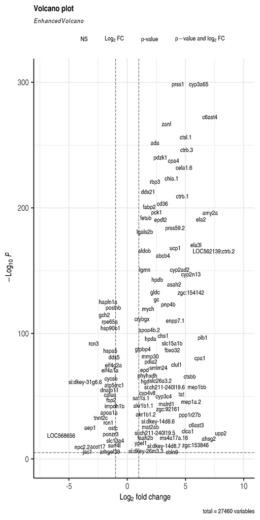

```r
fiveMplot = EnhancedVolcano(res5vM,
  lab = rowData(dds5vM)$SYMBOL,
  x = 'log2FoldChange',
  y = 'pvalue')
fiveMplot
```

```r
ggsave("outputs/fivevsMvolcano.pdf", height = 16, width = 8)
```

## Top Genes for expressed Day4 vs mouth Protruding

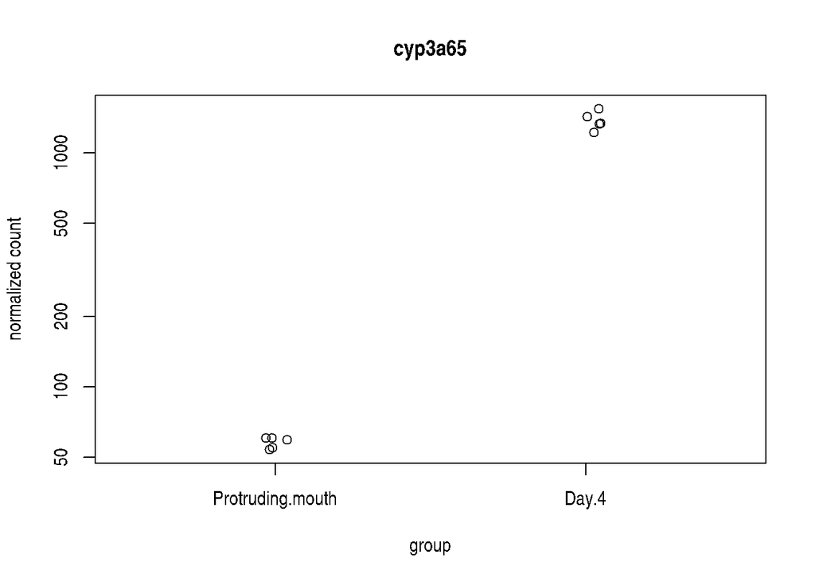

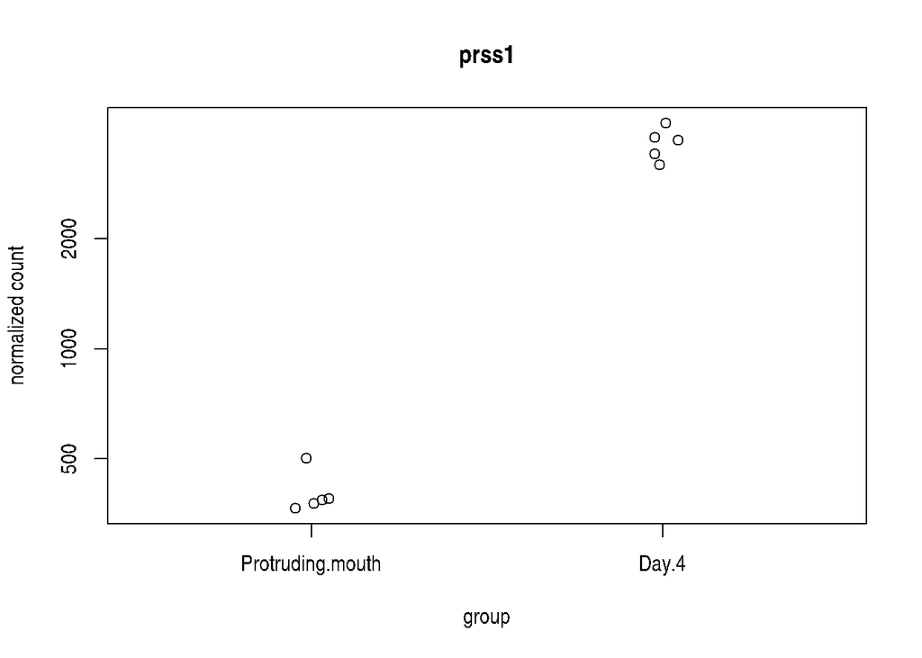

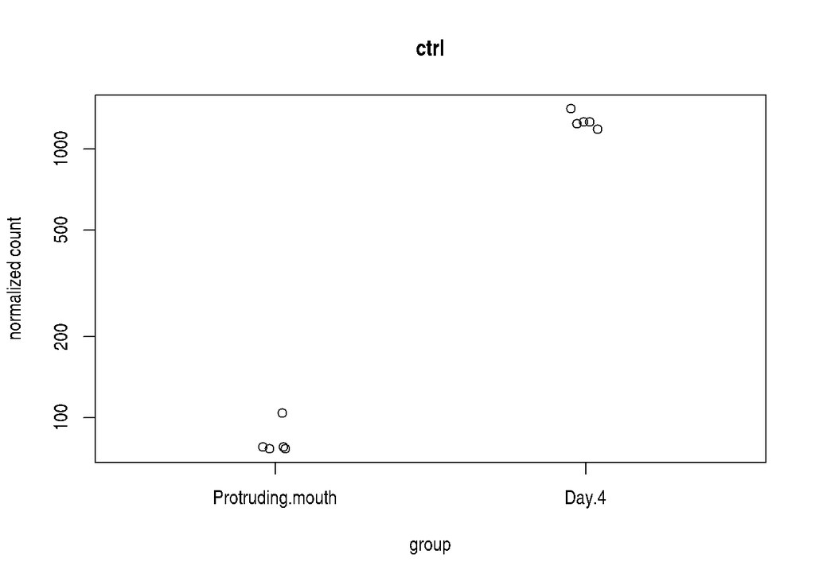

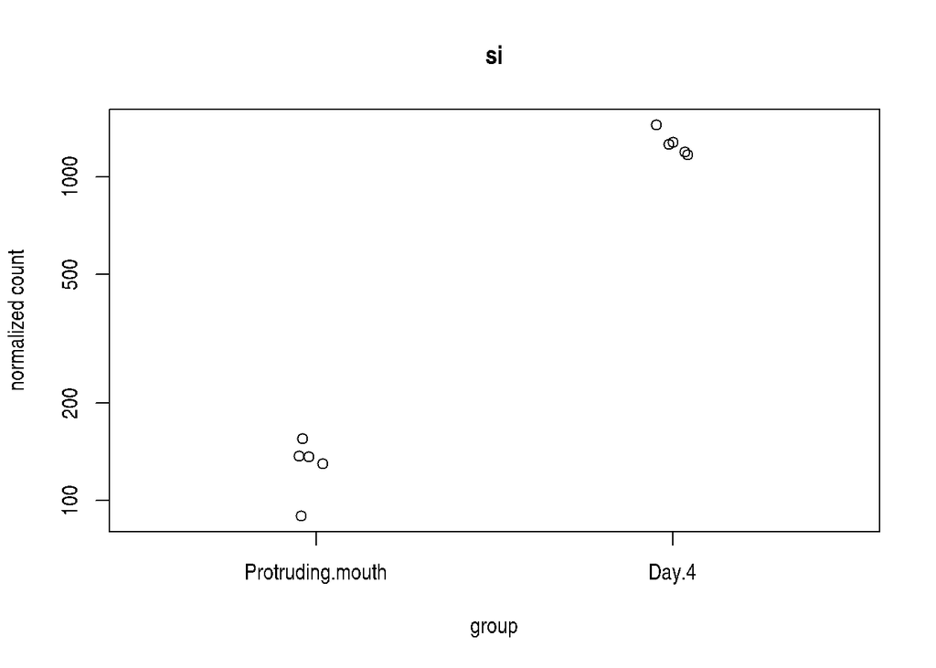

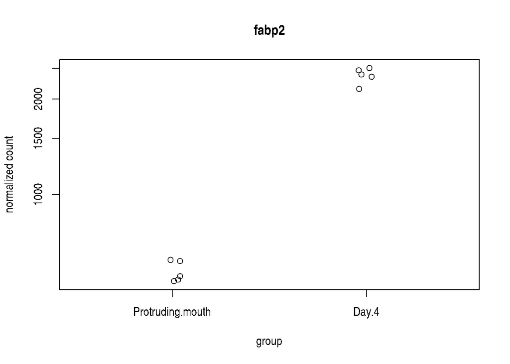

```r
(for (i in order(res4vM$padj, decreasing = F)[1:5]){
  plotCounts(dds4vM, gene=i, intgroup="stageName", main = "")
  title(rowData(dds4vM)[rownames(res4vM[i,]),]$SYMBOL)
})
```

### Volcano Plot

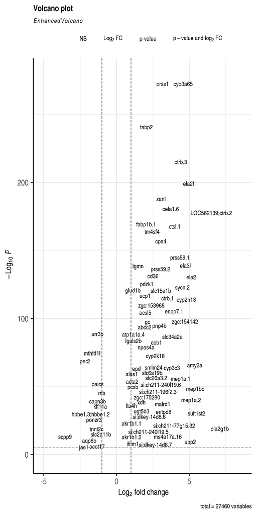

```r
fourMplot = EnhancedVolcano(res4vM,
  lab = rowData(dds4vM)$SYMBOL,
  x = 'log2FoldChange',
  y = 'pvalue')
fourMplot
```

```r
ggsave("outputs/fourvsMvolcano.pdf", height = 16, width = 8)
```

## significant genes 4v5

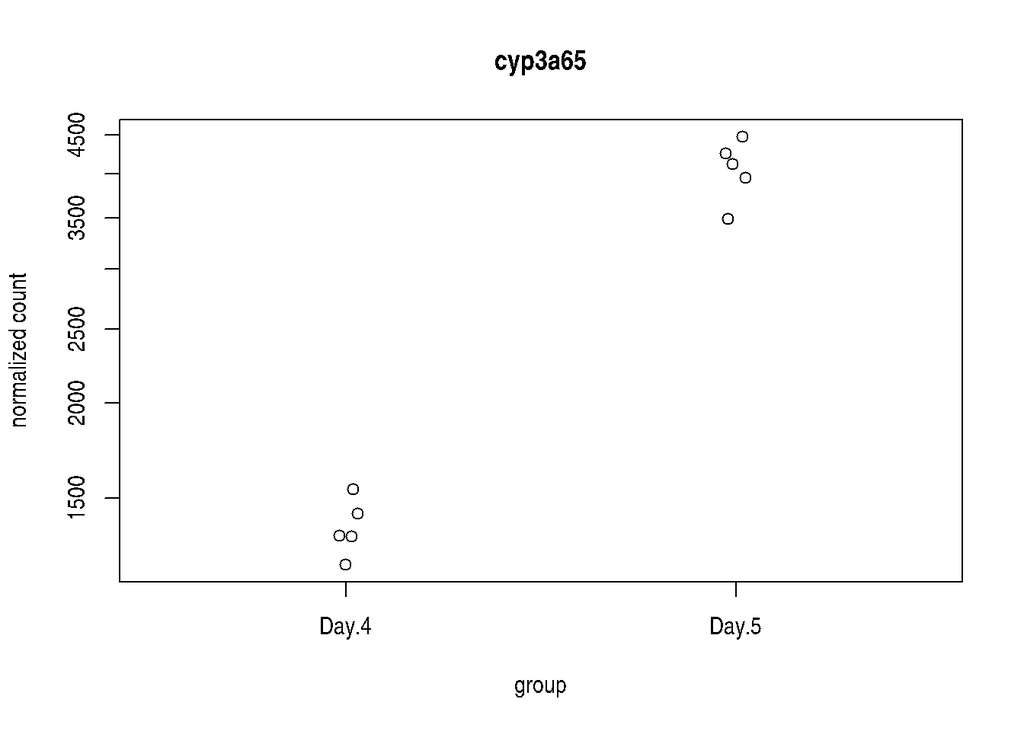

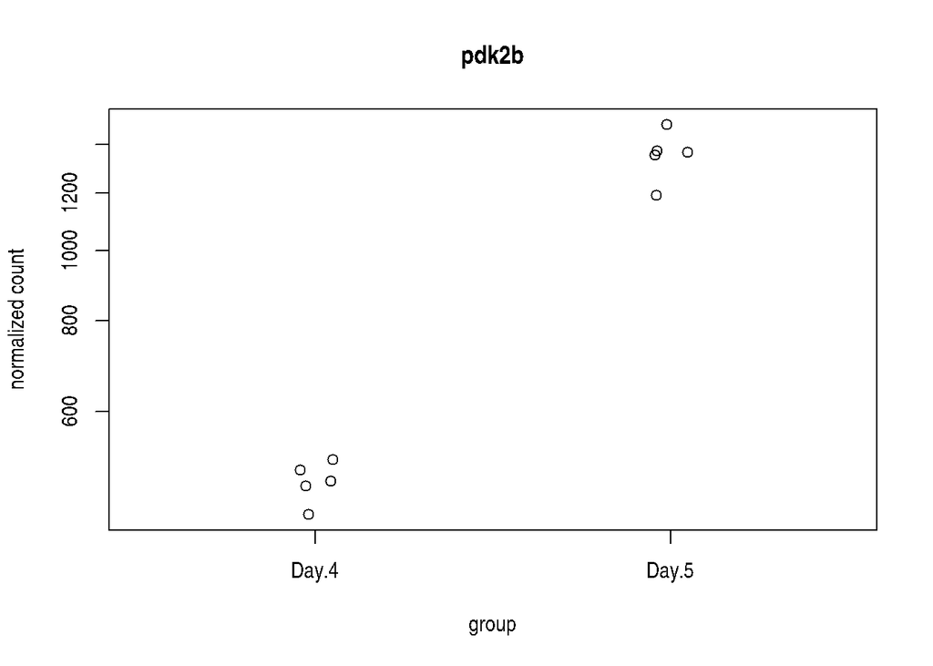

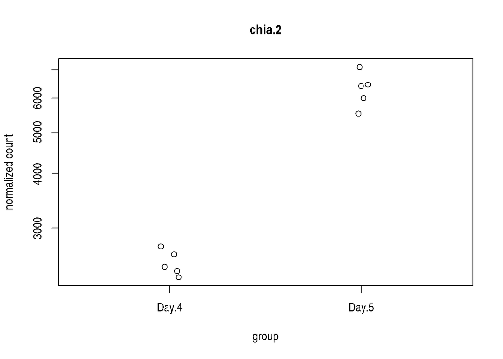

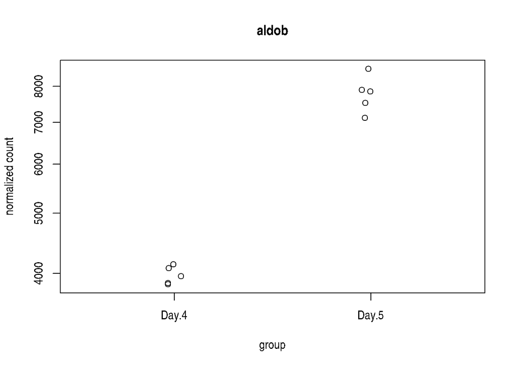

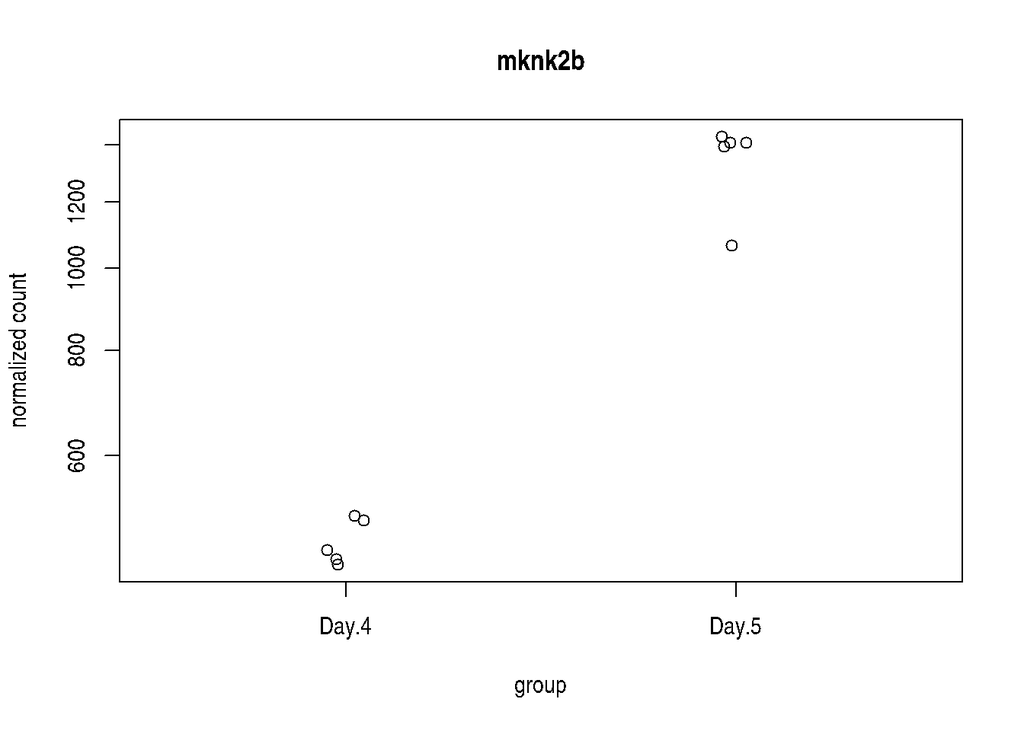

```r
(for (i in order(res4v5$padj, decreasing = F)[1:5]){
  plotCounts(dds4v5, gene=i, intgroup="stageName", main = "")
  title(rowData(dds4v5)[rownames(res4v5[i,]),]$SYMBOL)
})
```

### Volcano plot 4v5

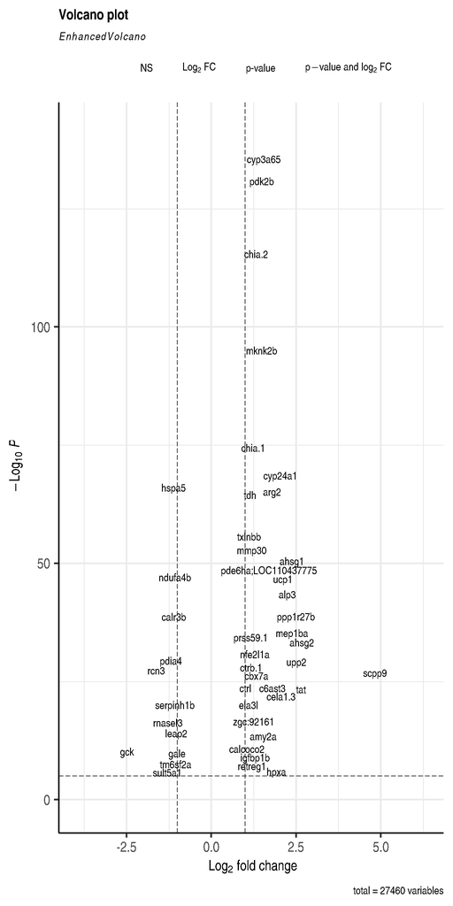

```r
fourfiveplot = EnhancedVolcano(res4v5,
  lab = rowData(dds4v5)$SYMBOL,
  x = 'log2FoldChange',
  y = 'pvalue')
fourfiveplot
```

```r
ggsave("outputs/fourvsfivevolcano.pdf", height = 16, width = 8)
```

from all of this we do see that Hox genes are not the most DEgenes by counts. Instead we see the two DE genes that seem to be related to the trypsin? ctrl and prss1.

Many of the other top genes are interspersed through many other gene ontologies, including fatty acid metaboloism/transport, and location specific markers i.e. (cyp3a65 is expressed in the membrane of these structures: digestive system, eye, gill, heart and ovary.)

## HOX genes only

Since this was my original question, let’s filter and generate a heatmap of just the HOX genes, and let’s see if we get some variability here.

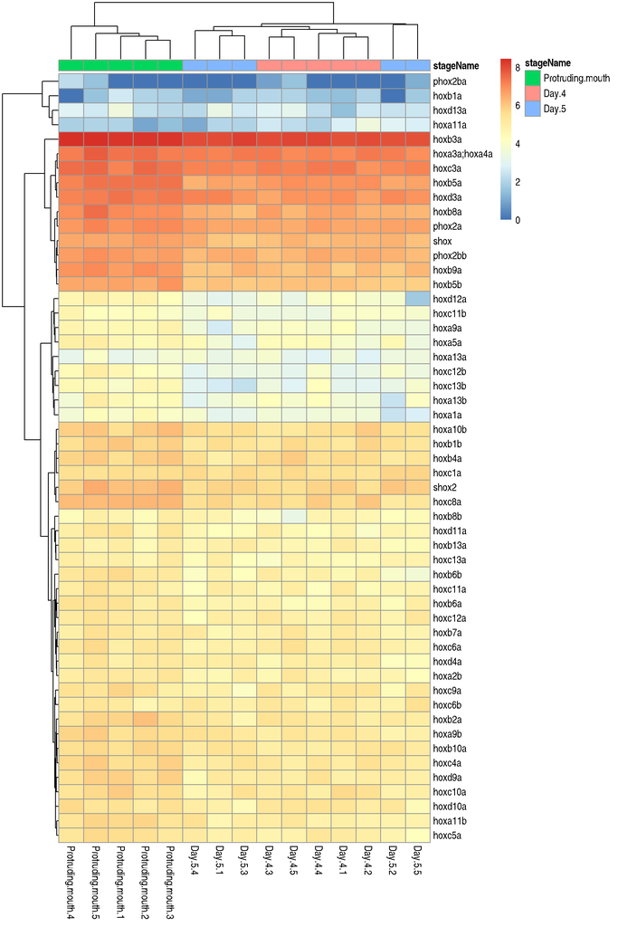

```r
library(pheatmap)
dds = readRDS("outputs/dds.rds")
ntd<-normTransform(dds)
select <- grep(rowData(ntd)$SYMBOL,pattern="hox")
df <- as.data.frame(colData(dds)[,"stageName"])
colnames(df)<-"stageName"
rownames(df)<-colnames(ntd)
pheatmap(assay(ntd)[select,], cluster_rows=TRUE, labels_row=grep(rowData(ntd)$SYMBOL,pattern="hox", value=TRUE),
         cluster_cols=TRUE, annotation_col=df)
```

From this we do see that unfortunately… all of the samples seem to just be relatively prolific in HOX expression across the three timepoints chosen. This may be due to the fact that these are later timepoints and are bulk samples. We capture the entire signal and as such we do not have the distinction of where these Hox genes are being expressed across the embryo, and we only know that the genes are being highly expressed. Still we do see some differences in the hox expression. Particularly, there does seem to be some differences in expression between the Protruding mouth when compared to day 4 and 5.